# Project: Movies Data Analysis - [tmbd_movies]

### Busiest time of the year to release a Movie

```python
df.release_year.unique()
```

```
array([2015, 2014, 1977, 2009, 2010, 1999, 2001, 2008, 2011, 2002, 1994,
       2012, 2003, 1997, 2013, 1985, 2005, 2006, 2004, 1972, 1980, 2007,
       1979, 1984, 1983, 1995, 1992, 1981, 1996, 2000, 1982, 1998, 1989,
       1991, 1988, 1987, 1968, 1974, 1975, 1962, 1964, 1971, 1990, 1961,
       1960, 1976, 1993, 1967, 1963, 1986, 1973, 1970, 1965, 1969, 1978,
       1966], dtype=int64)
```

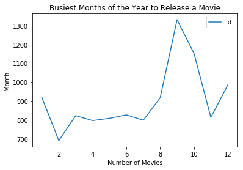

```python
df_time=pd.DataFrame(df.query("id >0").groupby(['month']).count()['id'])
df_time.head()

df_time.plot.line();
plt.xlabel('Number of Movies');
plt.ylabel('Month');
plt.title("Busiest Months of the Year to Release a Movie");
```

The busiest Months of the year to release movies seems to be September and October

Let's check for a individual years like 2014 and 2015 if trends are similar.

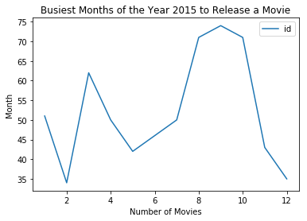

```python
df_time_2015=pd.DataFrame(df.query("release_year =='2015'").groupby(['month']).count()['id'])
df_time_2015.head()

df_time_2015.plot.line();
plt.xlabel('Number of Movies');
plt.ylabel('Month');
plt.title("Busiest Months of the Year 2015 to Release a Movie");
```

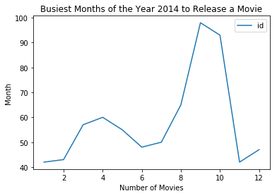

```python
df_time_2014=pd.DataFrame(df.query("release_year =='2014'").groupby(['month']).count()['id'])
df_time_2014.head()

df_time_2014.plot.line();
plt.xlabel('Number of Movies');
plt.ylabel('Month');
plt.title("Busiest Months of the Year 2014 to Release a Movie");
```

The charts show an peak of movies release in the months of Sept and Oct in 2014 and 2015

```python
#Most popular genres
value = df.groupby(["genre_0"])['id'].count()
value.sort_values(ascending = False)
```

```
genre_0
Drama              2453
Comedy             2319
Action             1590
Horror              915
Adventure           586
Thriller            491
Documentary         432
Animation           403
Crime               381
Fantasy             272
Science Fiction     214
Romance             186
Family              144
Mystery             125
Music               100
TV Movie             78
War                  59
History              44
Western              42
Foreign               9
Name: id, dtype: int64
```

```python
df.id.nunique()
```

```
10865
```

## Conclusions

The dataset contains 56 years of movies data, cutting across several genres.

• From the dataset there are 10865 movies from different genres. 2453 movies are drama movies, 2319 are Comedy movies and 1590 Action movies. There are also 915 Horror movies, about 586 adventure and 491 Thriller movies.

• Avatar generated the most revenue and the most profit overall. It also ranks 12th on the all time most popular movie. It premiered in 2009 and was the most popular movie that year.

• The Warrior's Way has the highest budget moview. However it is not between the movies with highest profit. We assume that It's probably running loss.

• The most popular movie is the Adventure movie released in 2015, titled Jurassic World. Also having an excellent revenue and profit record.

• Talking about popularity & profit, from the visualization above we can notice a strong positive correllation between revenue and budget this means that in most cases the higher the budget for a movie there's a probability that the movie would generate as much profit.

• Don't you think this will affect profit? Well, looking at the other correllation matrix table and the scatter plot, we'd notice a positive correlation between profit and popularity. What this implies is that as people keep talking about a movie, recommending it and making the movie trend, the revenue less the budget increases and this is more money for the directors and every one concerned.

• So, if you are looking for a movie director to generate a lot of revenue for you then Steven Spielberg is the man for you.

• Christopher Nolan had a fair share of the recognition as he is the most popular movie director as gets the highest value in popularity 61.95.

• Let's look at runtime and popularity. The correlation between runtime and popularity depicts a low positive correlation. It means that the popularity of a movie does not really depend on its length. As mentioned above there are other factors that greatly influence popularity based on this dataset.

• The busiest time of the year to release a movie are the months of September and October.

## Limitation

• The final cost of making a movie was not given

• Social media comments or ratings were not given

• Details of the rating column was not given

• Also, from the correlation matrix table, Id was correlated with release year with a strong positive correlation but the id was just used to number the movie and has nothing to do with it the release year. This shows that correlation at times does not necessarily imply causation.

• Amount of people that streamed the movie was not given

```python
from subprocess import call
call(['python', '-m', 'nbconvert', 'Investigate_a_Dataset.ipynb'])
```

```
0
```